# Inflation Drivers: Post-COVID Analysis

Week 4: Variables

Riley Conlon

2024/12/11

# Introduction

# Inflation

## Consumer Price Index

Name: Consumer Price Index  
Units: Index  
Freq.: Monthly  
Transforms: Month-to-month percent change, annualized

### Plot Histogram

### ADF Results

```r
# Test for stationarity
stationary_test(table_cpi, var_name) %>% cat()
```

```
## ADF Test Results for  CPI
##  As-Is:  0.503781541677946
##  M/M:    0.539968279749874
##  Y/Y:    0.859304128428237
```

## Autocorrelation

### M/M AR(1) Model & Durbin-Watson

### M/M AR(1) Model Plots

### Y/Y AR(1) Model & Durbin-Watson

```r
print(
  summary(result_gas$Model_Y_Ya)
)
```

[output not shown]

```r
print(
  result_gas$DW_Y_Ya
  )
```

[output not shown]

### Y/Y AR(1) Model Plots

[figure not shown]

```r
print(result_gas$plot_Y_Ya)
```

# Energy

## Gasoline, All Formulations

Units: Nominal $  
Freq.: Weekly  
Transforms: Inflation adjustment; month-to-month, annualized

### Plot Histogram

### ADF Results

```r
stationary_test(table_gas, var_name) %>% cat()
```

```
## ADF Test Results for  Gasoline
##  As-Is:  0.662265863342159
##  M/M:    0.01
##  Y/Y:    0.733140563973705
```

### M/M Model Results and Durbin-Watson

### M/M Model Plots

### Y/Y Model Results and Durbin-Watson

```r
print(
  summary(result_gas$Model_Y_Ya)
)
```

```
##
## Call:
## lm(formula = as.formula(paste(response_col, "~", predictor_col)),
##     data = list_results[["merged_df"]])
##
## Residuals:
##       Min        1Q    Median        3Q       Max
## -0.037745 -0.013533 -0.003195  0.010524  0.039679
##
## Coefficients:
##             Estimate Std. Error t value Pr(>|t|)
## (Intercept) 0.036716   0.002176   16.87  < 2e-16 ***
## Gas_Y_Ya    0.070621   0.009543    7.40 2.31e-10 ***
## ---
## Signif. codes:  0 '***' 0.001 '**' 0.01 '*' 0.05 '.' 0.1 ' ' 1
##
## Residual standard error: 0.0184 on 70 degrees of freedom
## Multiple R-squared:  0.4389, Adjusted R-squared:  0.4309
## F-statistic: 54.77 on 1 and 70 DF,  p-value: 2.314e-10
```

```r
print(
  result_gas$DW_Y_Ya
  )
```

```
##
##  Durbin-Watson test
##
## data:  list_results[["Model_Y_Ya"]]
## DW = 0.071594, p-value < 2.2e-16
## alternative hypothesis: true autocorrelation is greater than 0
```

### Y/Y Model Plots

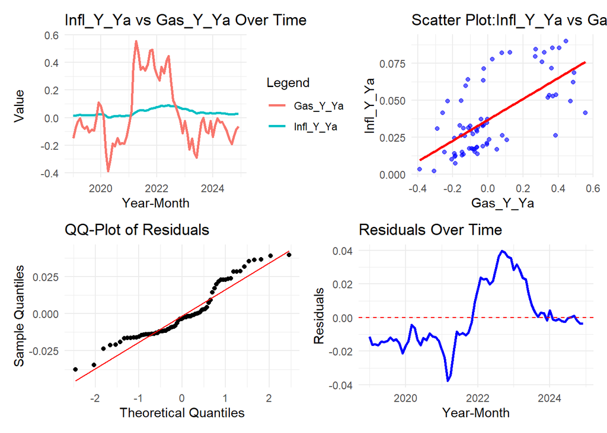

```r
print(result_gas$plot_Y_Ya)
```

# Supply Chain Difficulties

## Over-Water Freight

Units: Index  
Freq.: Monthly  
Transforms:

### Plot Histogram

### ADF Results

```r
stationary_test(table_water, var_name) %>% cat()
```

```
## ADF Test Results for  Water_Shipping
##  As-Is:  0.580696509633086
##  M/M:    0.171606035802629
##  Y/Y:    0.581362129894707
```

### M/M Model Results and Durbin-Watson

### M/M Model Plots

### Y/Y Model Results and Durbin-Watson

```r
print(
  summary(result_water$Model_Y_Ya)
)
```

```
##
## Call:
## lm(formula = as.formula(paste(response_col, "~", predictor_col)),
##     data = list_results[["merged_df"]])
##
## Residuals:
##        Min         1Q     Median         3Q        Max
## -0.0240808 -0.0081004 -0.0002863  0.0093875  0.0291320
##
## Coefficients:
##               Estimate Std. Error t value Pr(>|t|)
## (Intercept)   0.023501   0.001586   14.82   <2e-16 ***
## Water_Fr_Y_Ya 0.202117   0.012311   16.42   <2e-16 ***
## ---
## Signif. codes:  0 '***' 0.001 '**' 0.01 '*' 0.05 '.' 0.1 ' ' 1
##
## Residual standard error: 0.01115 on 70 degrees of freedom
## Multiple R-squared:  0.7938, Adjusted R-squared:  0.7909
## F-statistic: 269.5 on 1 and 70 DF,  p-value: < 2.2e-16
```

```r
print(
  result_water$DW_Y_Ya
  )
```

```
##
##  Durbin-Watson test
##
## data:  list_results[["Model_Y_Ya"]]
## DW = 0.23122, p-value < 2.2e-16
## alternative hypothesis: true autocorrelation is greater than 0
```

### Y/Y Model Plots

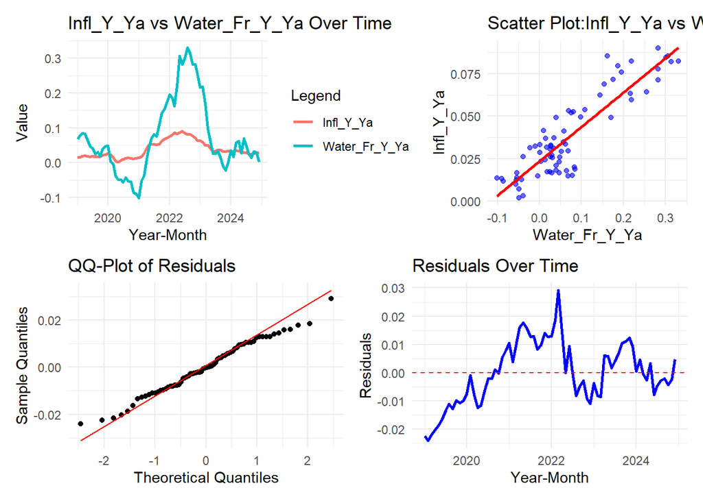

```r
print(result_water$plot_Y_Ya)
```

## Over-Land Trucking Freight

Units: Index  
Freq.: Monthly  
Transforms:

### Plot Histogram

### ADF Results

```r
stationary_test(table_truck, var_name) %>% cat()
```

```
## ADF Test Results for  Truck_Shipping
##  As-Is:  0.610998847752569
##  M/M:    0.446226764953538
##  Y/Y:    0.551511105796443
```

### M/M Model Results and Durbin-Watson

### M/M Model Plots

### Y/Y Model Results and Durbin-Watson

```r
print(
  summary(result_truck$Model_Y_Ya)
)
```

```
##
## Call:
## lm(formula = as.formula(paste(response_col, "~", predictor_col)),
##     data = list_results[["merged_df"]])
##
## Residuals:
##       Min        1Q    Median        3Q       Max
## -0.026469 -0.015953 -0.003266  0.014975  0.035994
##
## Coefficients:
##                     Estimate Std. Error t value Pr(>|t|)
## (Intercept)         0.031067   0.002194  14.161  < 2e-16 ***
## Truck_Shipping_Y_Ya 0.176960   0.020856   8.485 2.34e-12 ***
## ---
## Signif. codes:  0 '***' 0.001 '**' 0.01 '*' 0.05 '.' 0.1 ' ' 1
##
## Residual standard error: 0.01725 on 70 degrees of freedom
## Multiple R-squared:  0.507,  Adjusted R-squared:    0.5
## F-statistic: 71.99 on 1 and 70 DF,  p-value: 2.338e-12
```

```r
print(
  result_truck$DW_Y_Ya
  )
```

```
##
##  Durbin-Watson test
##
## data:  list_results[["Model_Y_Ya"]]
## DW = 0.053246, p-value < 2.2e-16
## alternative hypothesis: true autocorrelation is greater than 0
```

### Y/Y Model Plots

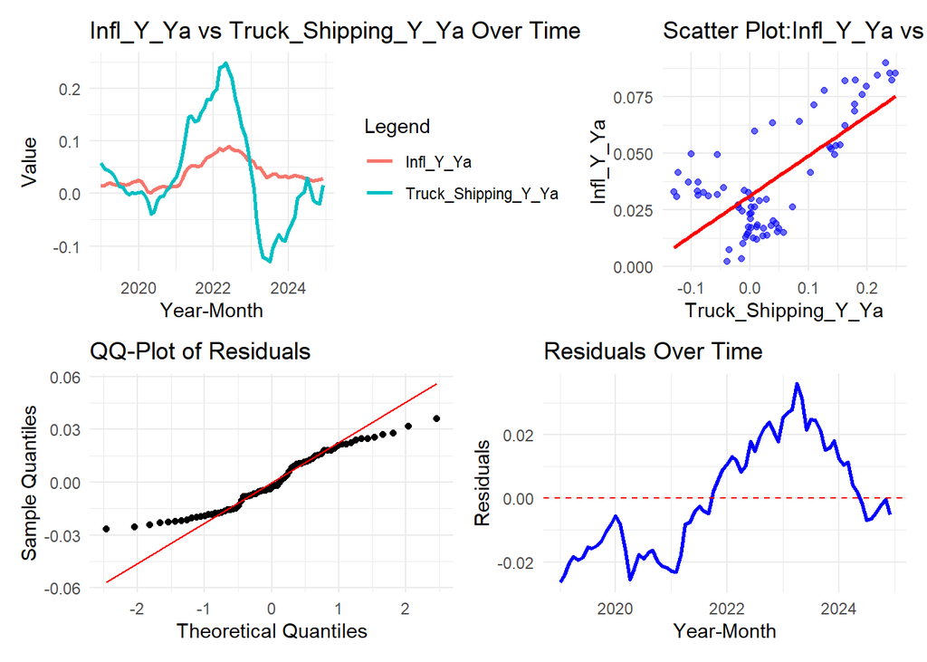

```r
print(result_truck$plot_Y_Ya)
```

## Global Supply Chain Pressure

Units: Index  
Freq.: Monthly  
Transforms:

## Container Freight Index

Units:  
Freq.:  
Transforms:

# Corporate Profits & Price Gouging

## Corporate Profits

Units: Nominal $  
Freq.: Quarterly  
Transforms:

## Total Inventories

Units: Nominal $  
Freq.: Monthly  
Transforms:

### Plot Histogram

### ADF Results

```r
stationary_test(table_total_inv, var_name) %>% cat()
```

```
## ADF Test Results for  Total_Inv
##  As-Is:  0.482213289303305
##  M/M:    0.472865756144462
##  Y/Y:    0.361899574321564
```

### M/M Model Results and Durbin-Watson

### M/M Model Plots

### Y/Y Model Results and Durbin-Watson

```r
print(
  summary(result_total_inv$Model_Y_Ya)
)
```

```
##
## Call:
## lm(formula = as.formula(paste(response_col, "~", predictor_col)),
##     data = list_results[["merged_df"]])
##
## Residuals:
##       Min        1Q    Median        3Q       Max
## -0.033394 -0.007623  0.004490  0.011051  0.017392
##
## Coefficients:
##                Estimate Std. Error t value Pr(>|t|)
## (Intercept)    0.034088   0.001718   19.85   <2e-16 ***
## Total_Inv_Y_Ya 0.448818   0.038350   11.70   <2e-16 ***
## ---
## Signif. codes:  0 '***' 0.001 '**' 0.01 '*' 0.05 '.' 0.1 ' ' 1
##
## Residual standard error: 0.01429 on 70 degrees of freedom
## Multiple R-squared:  0.6618, Adjusted R-squared:  0.6569
## F-statistic:   137 on 1 and 70 DF,  p-value: < 2.2e-16
```

```r
print(
  result_total_inv$DW_Y_Ya
  )
```

```
##
##  Durbin-Watson test
##
## data:  list_results[["Model_Y_Ya"]]
## DW = 0.13738, p-value < 2.2e-16
## alternative hypothesis: true autocorrelation is greater than 0
```

### Y/Y Model Plots

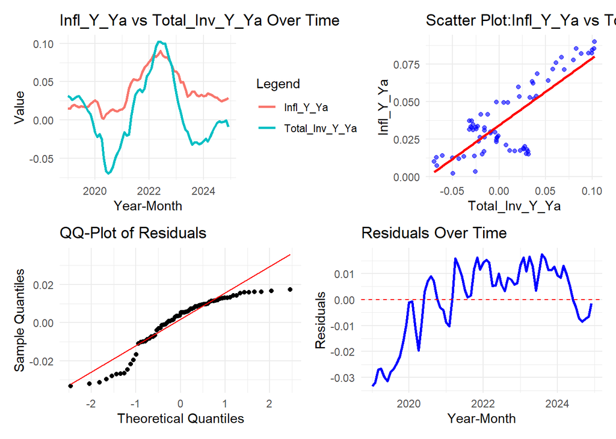

```r
print(result_total_inv$plot_Y_Ya)
```

## Manufacturing Inventories

Units: Nominal $  
Freq.: Monthly  
Transforms:

### Plot Histogram

### ADF Results

```r
stationary_test(table_manu_inv, var_name) %>% cat()
```

```
## ADF Test Results for  Manu_Inv
##  As-Is:  0.575811029256801
##  M/M:    0.563711380109849
##  Y/Y:    0.241482526373462
```

### M/M Model Results and Durbin-Watson

### M/M Model Plots

### Y/Y Model Results and Durbin-Watson

```r
print(
  summary(result_manu_inv$Model_Y_Ya)
)
```

```
##
## Call:
## lm(formula = as.formula(paste(response_col, "~", predictor_col)),
##     data = list_results[["merged_df"]])
##
## Residuals:
##       Min        1Q    Median        3Q       Max
## -0.033994 -0.018422  0.001045  0.012317  0.039936
##
## Coefficients:
##               Estimate Std. Error t value Pr(>|t|)
## (Intercept)   0.036177   0.002464  14.685  < 2e-16 ***
## Manu_Inv_Y_Ya 0.401137   0.074894   5.356 1.03e-06 ***
## ---
## Signif. codes:  0 '***' 0.001 '**' 0.01 '*' 0.05 '.' 0.1 ' ' 1
##
## Residual standard error: 0.02069 on 70 degrees of freedom
## Multiple R-squared:  0.2907, Adjusted R-squared:  0.2806
## F-statistic: 28.69 on 1 and 70 DF,  p-value: 1.027e-06
```

```r
print(
  result_manu_inv$DW_Y_Ya
  )
```

```
##
##  Durbin-Watson test
##
## data:  list_results[["Model_Y_Ya"]]
## DW = 0.057912, p-value < 2.2e-16
## alternative hypothesis: true autocorrelation is greater than 0
```

### Y/Y Model Plots

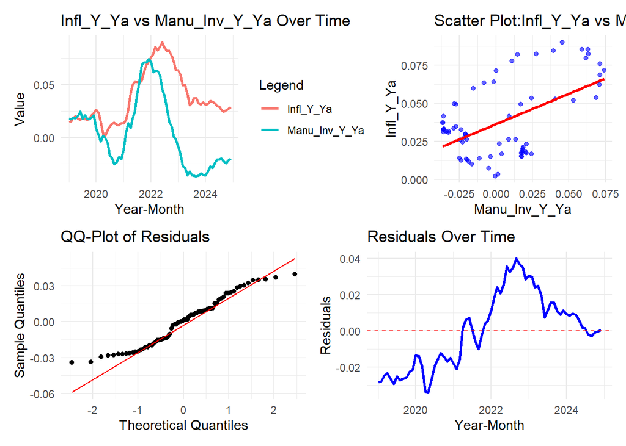

```r
print(result_manu_inv$plot_Y_Ya)
```

## Retail Inventories

Units: Nominal $  
Freq.: Monthly  
Transforms:

### Plot Histogram

### ADF Results

```r
stationary_test(table_retail_inv, var_name) %>% cat()
```

```
## ADF Test Results for  Retail_Inv
##  As-Is:  0.542883268231189
##  M/M:    0.0662714942803982
##  Y/Y:    0.448609215734219
```

### M/M Model Results and Durbin-Watson

### M/M Model Plots

### Y/Y Model Results and Durbin-Watson

```r
print(
  summary(result_retail_inv$Model_Y_Ya)
)
```

```
##
## Call:
## lm(formula = as.formula(paste(response_col, "~", predictor_col)),
##     data = list_results[["merged_df"]])
##
## Residuals:
##       Min        1Q    Median        3Q       Max
## -0.031121 -0.015665 -0.003645  0.014270  0.040999
##
## Coefficients:
##                 Estimate Std. Error t value Pr(>|t|)
## (Intercept)     0.037040   0.002248  16.475  < 2e-16 ***
## Retail_Inv_Y_Ya 0.272376   0.039907   6.825  2.6e-09 ***
## ---
## Signif. codes:  0 '***' 0.001 '**' 0.01 '*' 0.05 '.' 0.1 ' ' 1
##
## Residual standard error: 0.01903 on 70 degrees of freedom
## Multiple R-squared:  0.3996, Adjusted R-squared:  0.391
## F-statistic: 46.58 on 1 and 70 DF,  p-value: 2.597e-09
```

```r
print(
  result_retail_inv$DW_Y_Ya
  )
```

```
##
##  Durbin-Watson test
##
## data:  list_results[["Model_Y_Ya"]]
## DW = 0.090863, p-value < 2.2e-16
## alternative hypothesis: true autocorrelation is greater than 0
```

### Y/Y Model Plots

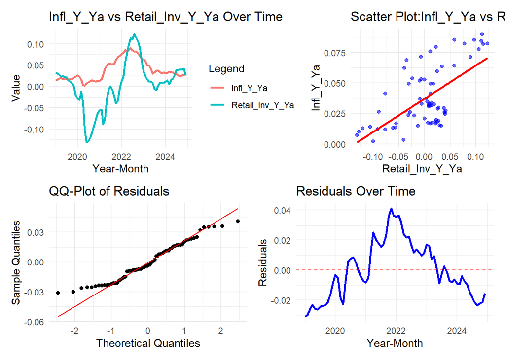

```r
print(result_retail_inv$plot_Y_Ya)
```

## Wholesale Inventories

Units: Nominal $  
Freq.: Monthly  
Transforms:

### Plot Histogram

### ADF Results

```r
stationary_test(table_ws_inv, var_name) %>% cat()
```

```
## ADF Test Results for  Wholesale_Inv
##  As-Is:  0.249617802219305
##  M/M:    0.787202313968365
##  Y/Y:    0.084368496955972
```

### M/M Model Results and Durbin-Watson

### M/M Model Plots

### Y/Y Model Results and Durbin-Watson

```r
print(
  summary(result_ws_inv$Model_Y_Ya)
)
```

```
##
## Call:
## lm(formula = as.formula(paste(response_col, "~", predictor_col)),
##     data = list_results[["merged_df"]])
##
## Residuals:
##       Min        1Q    Median        3Q       Max
## -0.030985 -0.008675  0.003292  0.009945  0.019415
##
## Coefficients:
##                    Estimate Std. Error t value Pr(>|t|)
## (Intercept)        0.032268   0.001701   18.97   <2e-16 ***
## Wholesale_Inv_Y_Ya 0.303439   0.024784   12.24   <2e-16 ***
## ---
## Signif. codes:  0 '***' 0.001 '**' 0.01 '*' 0.05 '.' 0.1 ' ' 1
##
## Residual standard error: 0.01386 on 70 degrees of freedom
## Multiple R-squared:  0.6817, Adjusted R-squared:  0.6771
## F-statistic: 149.9 on 1 and 70 DF,  p-value: < 2.2e-16
```

```r
print(
  result_ws_inv$DW_Y_Ya
  )
```

```
##
##  Durbin-Watson test
##
## data:  list_results[["Model_Y_Ya"]]
## DW = 0.13848, p-value < 2.2e-16
## alternative hypothesis: true autocorrelation is greater than 0
```

### Y/Y Model Plots

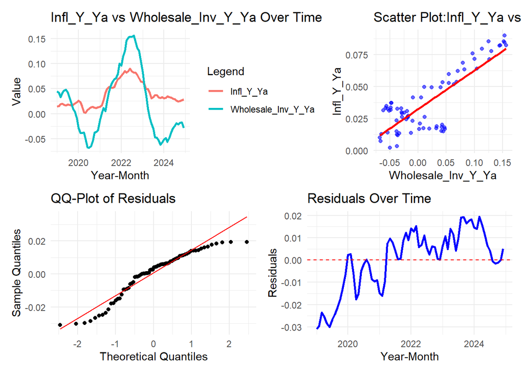

```r
print(result_ws_inv$plot_Y_Ya)
```

## Inventory-to-Sale Ratio

Units: Ratio  
Freq.: Monthly  
Transforms:

### Plot Histogram

### ADF Results

```r
stationary_test(table_its, var_name) %>% cat()
```

```
## ADF Test Results for  Inv_to_Sales
##  As-Is:  0.648156457735276
##  M/M:    0.01
##  Y/Y:    0.614057145704769
```

### M/M Model Results and Durbin-Watson

### M/M Model Plots

### Y/Y Model Results and Durbin-Watson

```r
print(
  summary(result_its$Model_Y_Ya)
)
```

```
##
## Call:
## lm(formula = as.formula(paste(response_col, "~", predictor_col)),
##     data = list_results[["merged_df"]])
##
## Residuals:
##       Min        1Q    Median        3Q       Max
## -0.035784 -0.020117 -0.006825  0.014927  0.052042
##
## Coefficients:
##                    Estimate Std. Error t value Pr(>|t|)
## (Intercept)        0.038075   0.002895  13.151   <2e-16 ***
## Inv_to_Sales_Y_Ya -0.002058   0.028166  -0.073    0.942
## ---
## Signif. codes:  0 '***' 0.001 '**' 0.01 '*' 0.05 '.' 0.1 ' ' 1
##
## Residual standard error: 0.02456 on 70 degrees of freedom
## Multiple R-squared:  7.629e-05,  Adjusted R-squared:  -0.01421
## F-statistic: 0.005341 on 1 and 70 DF,  p-value: 0.9419
```

```r
print(
  result_its$DW_Y_Ya
  )
```

```
##
##  Durbin-Watson test
##
## data:  list_results[["Model_Y_Ya"]]
## DW = 0.034882, p-value < 2.2e-16
## alternative hypothesis: true autocorrelation is greater than 0
```

### Y/Y Model Plots

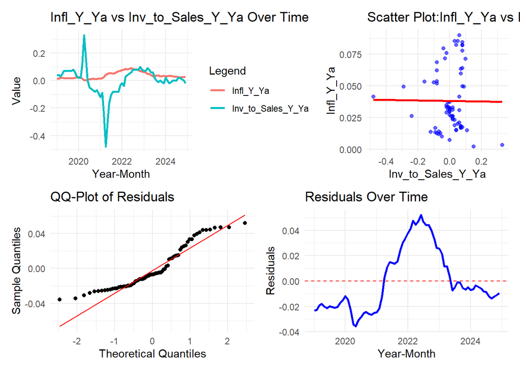

```r
print(result_its$plot_Y_Ya)
```

## Producer Price Index, All Items less Fuel

Units: Index  
Freq.: Monthly  
Transforms:

### Plot Histogram

### ADF Results

```r
stationary_test(table_ppi, var_name) %>% cat()
```

```
## ADF Test Results for  PPI_less_Fuel
##  As-Is:  0.750136459352346
##  M/M:    0.511792937165164
##  Y/Y:    0.360415413138713
```

### M/M Model Results and Durbin-Watson

### M/M Model Plots

### Y/Y Model Results and Durbin-Watson

```r
print(
  summary(result_ppi$Model_Y_Ya)
)
```

```
##
## Call:
## lm(formula = as.formula(paste(response_col, "~", predictor_col)),
##     data = list_results[["merged_df"]])
##
## Residuals:
##       Min        1Q    Median        3Q       Max
## -0.024338 -0.014143 -0.003042  0.008940  0.035456
##
## Coefficients:
##                    Estimate Std. Error t value Pr(>|t|)
## (Intercept)        0.025577   0.002362  10.827  < 2e-16 ***
## PPI_less_Fuel_Y_Ya 0.307373   0.033168   9.267 8.58e-14 ***
## ---
## Signif. codes:  0 '***' 0.001 '**' 0.01 '*' 0.05 '.' 0.1 ' ' 1
##
## Residual standard error: 0.01646 on 70 degrees of freedom
## Multiple R-squared:  0.5509, Adjusted R-squared:  0.5445
## F-statistic: 85.88 on 1 and 70 DF,  p-value: 8.58e-14
```

```r
print(
  result_ppi$DW_Y_Ya
  )
```

```
##
##  Durbin-Watson test
##
## data:  list_results[["Model_Y_Ya"]]
## DW = 0.052029, p-value < 2.2e-16
## alternative hypothesis: true autocorrelation is greater than 0
```

### Y/Y Model Plots

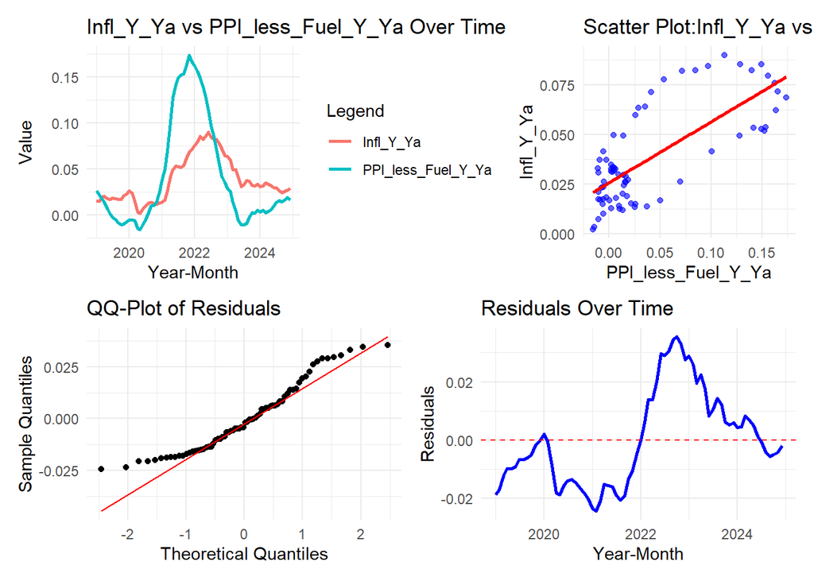

```r
print(result_ppi$plot_Y_Ya)
```

# Wages and Worker Power

## Real Personal Income

Units: Real $  
Freq.: Monthly  
Transforms:

### Plot Histogram

### ADF Results

```r
stationary_test(table_rpi, var_name) %>% cat()
```

```
## ADF Test Results for  Personal_Income
##  As-Is:  0.300734975291968
##  M/M:    0.0174270725416247
##  Y/Y:    0.37984169615785
```

### M/M Model Results and Durbin-Watson

### M/M Model Plots

### Y/Y Model Results and Durbin-Watson

```r
print(
  summary(result_rpi$Model_Y_Ya)
)
```

```
##
## Call:
## lm(formula = as.formula(paste(response_col, "~", predictor_col)),
##     data = list_results[["merged_df"]])
##
## Residuals:
##      Min       1Q   Median       3Q      Max
## -0.02869 -0.01525 -0.00640  0.01053  0.06383
##
## Coefficients:
##              Estimate Std. Error t value Pr(>|t|)
## (Intercept)  0.046022   0.002639  17.442  < 2e-16 ***
## RPI_Y_Ya    -0.296679   0.047235  -6.281 2.48e-08 ***
## ---
## Signif. codes:  0 '***' 0.001 '**' 0.01 '*' 0.05 '.' 0.1 ' ' 1
##
## Residual standard error: 0.01964 on 70 degrees of freedom
## Multiple R-squared:  0.3604, Adjusted R-squared:  0.3513
## F-statistic: 39.45 on 1 and 70 DF,  p-value: 2.484e-08
```

```r
print(
  result_rpi$DW_Y_Ya
  )
```

```
##
##  Durbin-Watson test
##
## data:  list_results[["Model_Y_Ya"]]
## DW = 0.71332, p-value = 1.531e-10
## alternative hypothesis: true autocorrelation is greater than 0
```

### Y/Y Model Plots

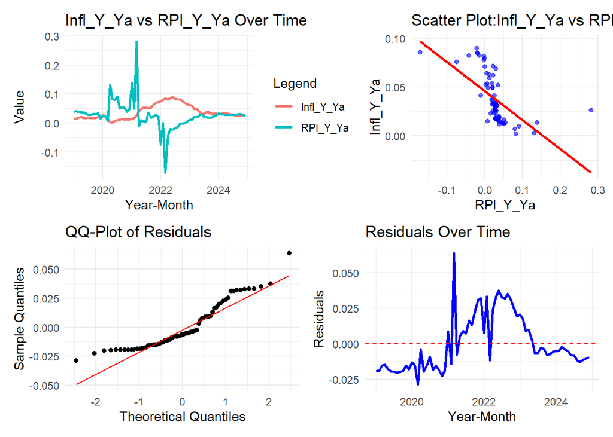

```r
print(result_rpi$plot_Y_Ya)
```

## Employment Cost Index

Units: Index  
Freq.: Quarterly  
Transforms:

## Total Unemployment

Units: Count  
Freq.: Monthly  
Transforms:

### Plot Histogram

### ADF Results

```r
stationary_test(table_unempl, var_name) %>% cat()
```

```
## ADF Test Results for  Unemployment
##  As-Is:  0.331468218136405
##  M/M:    0.0193421701833759
##  Y/Y:    0.460013642102817
```

### M/M Model Results and Durbin-Watson

### M/M Model Plots

### Y/Y Model Results and Durbin-Watson

```r
print(
  summary(result_unempl$Model_Y_Ya)
)
```

```
##
## Call:
## lm(formula = as.formula(paste(response_col, "~", predictor_col)),
##     data = list_results[["merged_df"]])
##
## Residuals:
##       Min        1Q    Median        3Q       Max
## -0.027484 -0.012346 -0.006152  0.014216  0.040279
##
## Coefficients:
##                    Estimate Std. Error t value Pr(>|t|)
## (Intercept)        0.041103   0.002326  17.674  < 2e-16 ***
## Unemployment_Y_Ya -0.023206   0.003542  -6.552  8.1e-09 ***
## ---
## Signif. codes:  0 '***' 0.001 '**' 0.01 '*' 0.05 '.' 0.1 ' ' 1
##
## Residual standard error: 0.01934 on 70 degrees of freedom
## Multiple R-squared:  0.3801, Adjusted R-squared:  0.3713
## F-statistic: 42.93 on 1 and 70 DF,  p-value: 8.105e-09
```

```r
print(
  result_unempl$DW_Y_Ya
  )
```

```
##
##  Durbin-Watson test
##
## data:  list_results[["Model_Y_Ya"]]
## DW = 0.14867, p-value < 2.2e-16
## alternative hypothesis: true autocorrelation is greater than 0
```

### Y/Y Model Plots

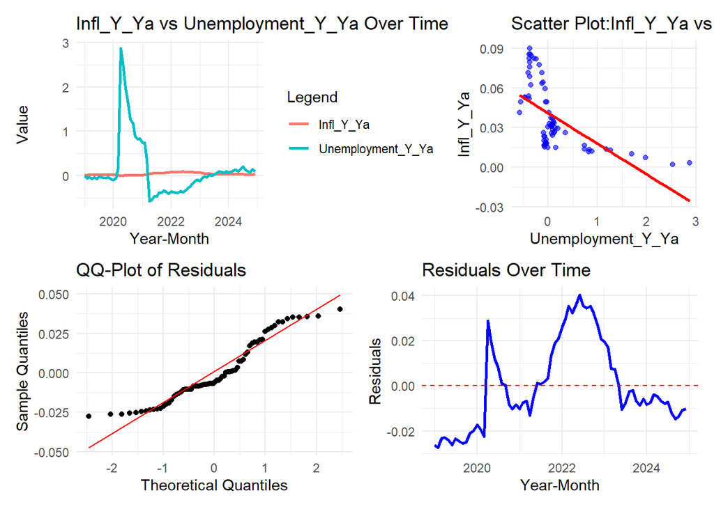

```r
print(result_unempl$plot_Y_Ya)
```

## Total Job Openings

Units: Count  
Freq.: Monthly  
Transforms:

### Plot Histogram

### ADF Results

```r
stationary_test(table_open, var_name) %>% cat()
```

```
## ADF Test Results for  Openings
##  As-Is:  0.912791094539385
##  M/M:    0.0646167362969114
##  Y/Y:    0.61968676595039
```

### M/M Model Results and Durbin-Watson

### M/M Model Plots

### Y/Y Model Results and Durbin-Watson

```r
print(
  summary(result_open$Model_Y_Ya)
)
```

```
##
## Call:
## lm(formula = as.formula(paste(response_col, "~", predictor_col)),
##     data = list_results[["merged_df"]])
##
## Residuals:
##       Min        1Q    Median        3Q       Max
## -0.029520 -0.018824 -0.004511  0.010762  0.050894
##
## Coefficients:
##               Estimate Std. Error t value Pr(>|t|)
## (Intercept)   0.036114   0.002653  13.611  < 2e-16 ***
## Openings_Y_Ya 0.034719   0.008621   4.027 0.000141 ***
## ---
## Signif. codes:  0 '***' 0.001 '**' 0.01 '*' 0.05 '.' 0.1 ' ' 1
##
## Residual standard error: 0.02213 on 70 degrees of freedom
## Multiple R-squared:  0.1881, Adjusted R-squared:  0.1765
## F-statistic: 16.22 on 1 and 70 DF,  p-value: 0.0001412
```

```r
print(
  result_open$DW_Y_Ya
  )
```

```
##
##  Durbin-Watson test
##
## data:  list_results[["Model_Y_Ya"]]
## DW = 0.042789, p-value < 2.2e-16
## alternative hypothesis: true autocorrelation is greater than 0
```

### Y/Y Model Plots

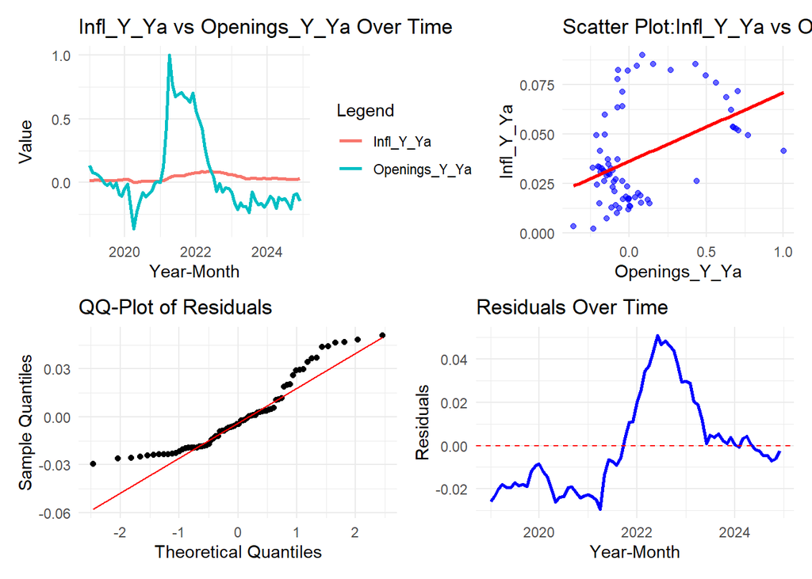

```r
print(result_open$plot_Y_Ya)
```

## Unemployment-to-Openings Ratio

Units: Ratio  
Freq.: Monthly  
Transforms:

### Plot Histogram

### ADF Results

```r
stationary_test(table_UtO, var_name) %>% cat()
```

```
## ADF Test Results for  Unemp_to_Opens
##  As-Is:  0.361074663340405
##  M/M:    0.01
##  Y/Y:    0.474468396034141
```

### M/M Model Results and Durbin-Watson

### M/M Model Plots

### Y/Y Model Results and Durbin-Watson

```r
print(
  summary(result_UtO$Model_Y_Ya)
)
```

```
##
## Call:
## lm(formula = as.formula(paste(response_col, "~", predictor_col)),
##     data = list_results[["merged_df"]])
##
## Residuals:
##       Min        1Q    Median        3Q       Max
## -0.043779 -0.015865 -0.005666  0.012571  0.047378
##
## Coefficients:
##                      Estimate Std. Error t value Pr(>|t|)
## (Intercept)          0.037978   0.002481  15.305  < 2e-16 ***
## Unemp_to_Opens_Y_Ya -0.012014   0.002390  -5.028 3.67e-06 ***
## ---
## Signif. codes:  0 '***' 0.001 '**' 0.01 '*' 0.05 '.' 0.1 ' ' 1
##
## Residual standard error: 0.02105 on 70 degrees of freedom
## Multiple R-squared:  0.2653, Adjusted R-squared:  0.2548
## F-statistic: 25.28 on 1 and 70 DF,  p-value: 3.666e-06
```

```r
print(
  result_UtO$DW_Y_Ya
  )
```

```
##
##  Durbin-Watson test
##
## data:  list_results[["Model_Y_Ya"]]
## DW = 0.1302, p-value < 2.2e-16
## alternative hypothesis: true autocorrelation is greater than 0
```

### Y/Y Model Plots

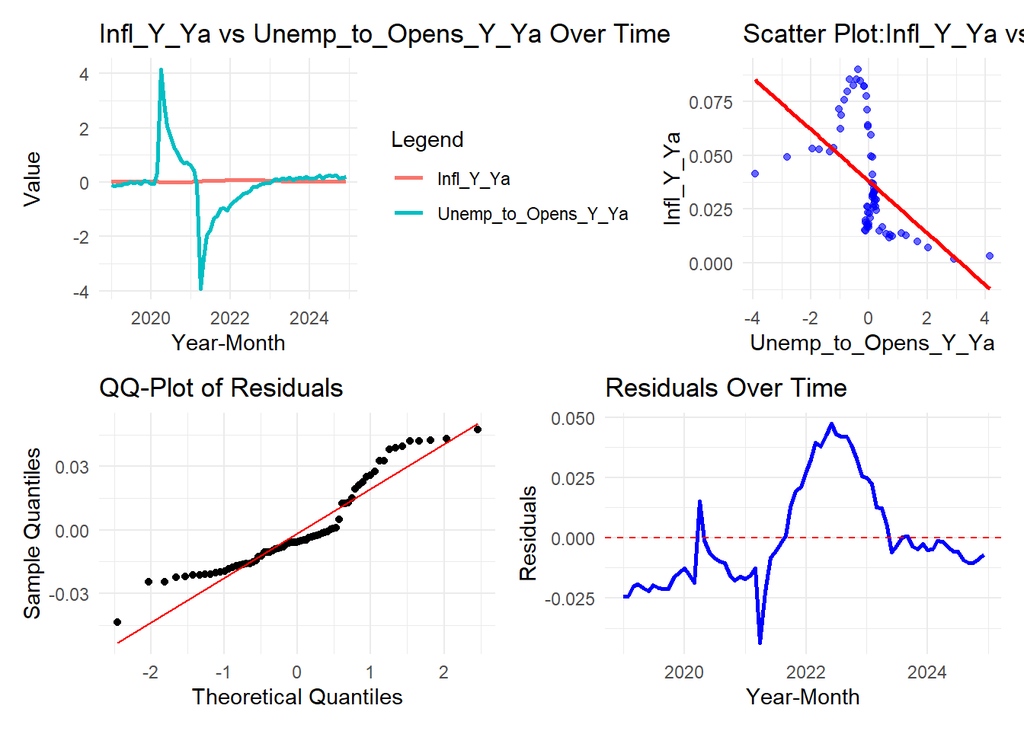

```r
print(result_UtO$plot_Y_Ya)
```

## Total Job Quits

Units: Count  
Freq.: Monthly  
Transforms:

### Plot Histogram

### ADF Results

```r
stationary_test(table_quits, var_name) %>% cat()
```

```
## ADF Test Results for  Quits
##  As-Is:  0.839263011267547
##  M/M:    0.0471328353135471
##  Y/Y:    0.553851887850418
```

### M/M Model Results and Durbin-Watson

### M/M Model Plots

### Y/Y Model Results and Durbin-Watson

```r
print(
  summary(result_quits$Model_Y_Ya)
)
```

```
##
## Call:
## lm(formula = as.formula(paste(response_col, "~", predictor_col)),
##     data = list_results[["merged_df"]])
##
## Residuals:
##       Min        1Q    Median        3Q       Max
## -0.035942 -0.019913 -0.003463  0.014903  0.051053
##
## Coefficients:
##             Estimate Std. Error t value Pr(>|t|)
## (Intercept) 0.037321   0.002683  13.910  < 2e-16 ***
## Quits_Y_Ya  0.041315   0.011914   3.468 0.000902 ***
## ---
## Signif. codes:  0 '***' 0.001 '**' 0.01 '*' 0.05 '.' 0.1 ' ' 1
##
## Residual standard error: 0.02269 on 70 degrees of freedom
## Multiple R-squared:  0.1466, Adjusted R-squared:  0.1344
## F-statistic: 12.03 on 1 and 70 DF,  p-value: 0.0009015
```

```r
print(
  result_quits$DW_Y_Ya
  )
```

```
##
##  Durbin-Watson test
##
## data:  list_results[["Model_Y_Ya"]]
## DW = 0.056027, p-value < 2.2e-16
## alternative hypothesis: true autocorrelation is greater than 0
```

### Y/Y Model Plots

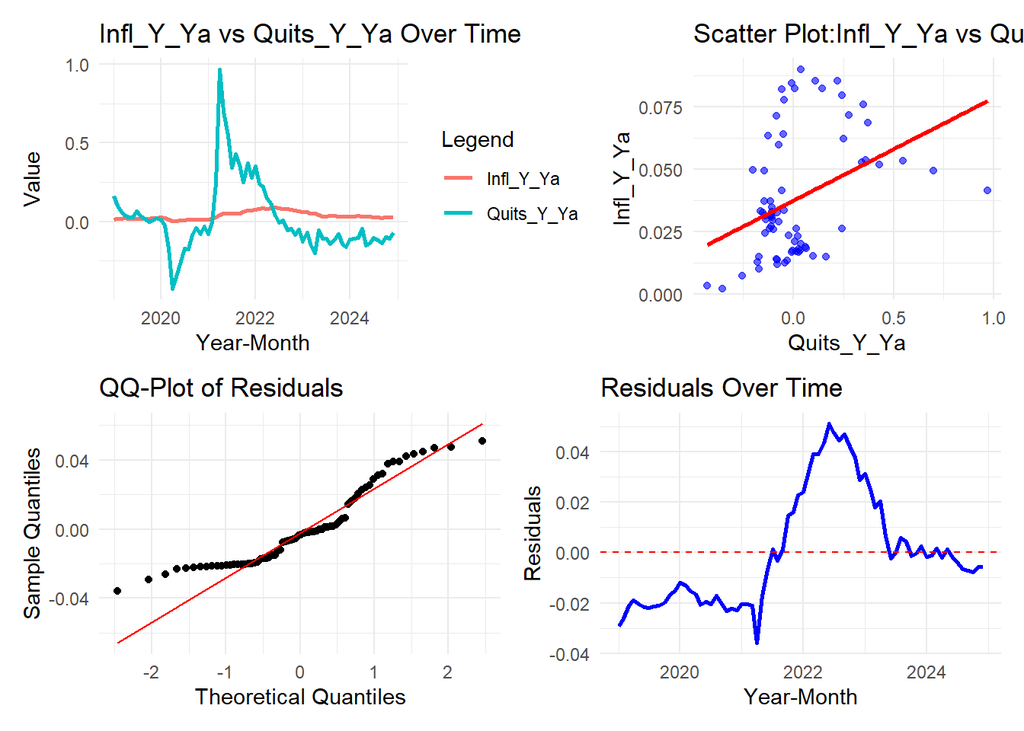

```r
print(result_quits$plot_Y_Ya)
```

## Total Layoffs

Units: Count  
Freq.: Monthly  
Transforms:

### Plot Histogram

### ADF Results

```r
stationary_test(table_layoffs, var_name) %>% cat()
```

```
## ADF Test Results for  Layoffs
##  As-Is:  0.0607045453747336
##  M/M:    0.0181372871929004
##  Y/Y:    0.0631638518438379
```

### M/M Model Results and Durbin-Watson

### M/M Model Plots

### Y/Y Model Results and Durbin-Watson

```r
print(
  summary(result_layoffs$Model_Y_Ya)
)
```

```
##
## Call:
## lm(formula = as.formula(paste(response_col, "~", predictor_col)),
##     data = list_results[["merged_df"]])
##
## Residuals:
##       Min        1Q    Median        3Q       Max
## -0.035687 -0.020179 -0.006865  0.013329  0.051965
##
## Coefficients:
##               Estimate Std. Error t value Pr(>|t|)
## (Intercept)   0.038679   0.002872  13.467   <2e-16 ***
## Layoffs_Y_Ya -0.004707   0.003014  -1.562    0.123
## ---
## Signif. codes:  0 '***' 0.001 '**' 0.01 '*' 0.05 '.' 0.1 ' ' 1
##
## Residual standard error: 0.02415 on 70 degrees of freedom
## Multiple R-squared:  0.03367,    Adjusted R-squared:  0.01986
## F-statistic: 2.439 on 1 and 70 DF,  p-value: 0.1229
```

```r
print(
  result_layoffs$DW_Y_Ya
  )
```

```
##
##  Durbin-Watson test
##
## data:  list_results[["Model_Y_Ya"]]
## DW = 0.071355, p-value < 2.2e-16
## alternative hypothesis: true autocorrelation is greater than 0
```

### Y/Y Model Plots

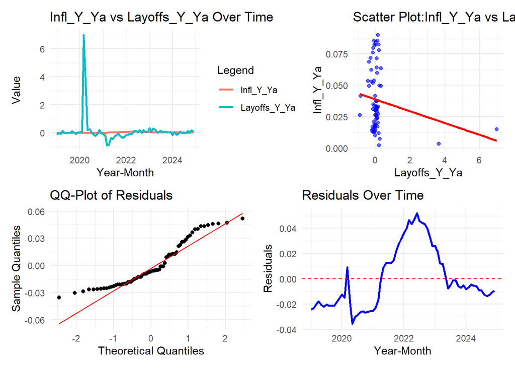

```r
print(result_layoffs$plot_Y_Ya)
```

## Labor Leverage Ratio

Units: Ratio  
Freq.: Monthly  
Transforms:

### Plot Histogram

### ADF Results

```r
stationary_test(table_LLR, var_name) %>% cat()
```

```
## ADF Test Results for  Labor_Leverage
##  As-Is:  0.875215706559505
##  M/M:    0.01
##  Y/Y:    0.671395938600906
```

### M/M Model Results and Durbin-Watson

### M/M Model Plots

### Y/Y Model Results and Durbin-Watson

```r
print(
  summary(result_LLR$Model_Y_Ya)
)
```

```
##
## Call:
## lm(formula = as.formula(paste(response_col, "~", predictor_col)),
##     data = list_results[["merged_df"]])
##
## Residuals:
##       Min        1Q    Median        3Q       Max
## -0.029007 -0.020428 -0.005343  0.015322  0.054172
##
## Coefficients:
##                     Estimate Std. Error t value Pr(>|t|)
## (Intercept)         0.037919   0.002793   13.58   <2e-16 ***
## Labor_Leverage_Y_Ya 0.007740   0.003379    2.29    0.025 *
## ---
## Signif. codes:  0 '***' 0.001 '**' 0.01 '*' 0.05 '.' 0.1 ' ' 1
##
## Residual standard error: 0.02369 on 70 degrees of freedom
## Multiple R-squared:  0.06972,    Adjusted R-squared:  0.05643
## F-statistic: 5.246 on 1 and 70 DF,  p-value: 0.02501
```

```r
print(
  result_LLR$DW_Y_Ya
  )
```

```
##
##  Durbin-Watson test
##
## data:  list_results[["Model_Y_Ya"]]
## DW = 0.049613, p-value < 2.2e-16
## alternative hypothesis: true autocorrelation is greater than 0
```

### Y/Y Model Plots

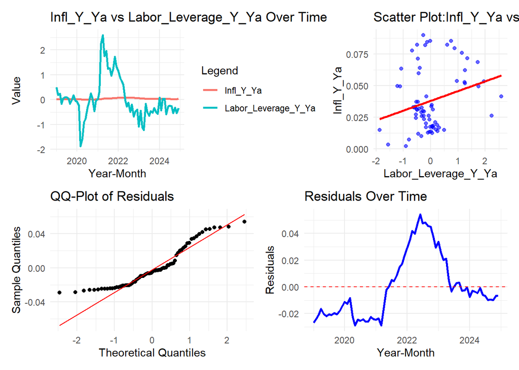

```r
print(result_LLR$plot_Y_Ya)
```

# Expectations

## Inflation Expectations, Derived from Bonds

Units: Percent %  
Freq.: Monthly  
Transforms:

### Plot Histogram

### ADF Results

```r
stationary_test(table_bonds, var_name) %>% cat()
```

```
## ADF Test Results for  Infl_Expect_Bonds
##  As-Is:  0.564602990093008
##  M/M:    0.01
##  Y/Y:    0.631107014251511
```

### M/M Model Results and Durbin-Watson

### M/M Model Plots

### Y/Y Model Results and Durbin-Watson

```r
print(
  summary(result_bonds$Model_Y_Ya)
)
```

```
##
## Call:
## lm(formula = as.formula(paste(response_col, "~", predictor_col)),
##     data = list_results[["merged_df"]])
##
## Residuals:
##       Min        1Q    Median        3Q       Max
## -0.030518 -0.013126 -0.002378  0.017742  0.043298
##
## Coefficients:
##                        Estimate Std. Error t value Pr(>|t|)
## (Intercept)            0.036724   0.002124  17.294  < 2e-16 ***
## Infl_Expect_Bonds_Y_Ya 0.017281   0.002213   7.807 4.14e-11 ***
## ---
## Signif. codes:  0 '***' 0.001 '**' 0.01 '*' 0.05 '.' 0.1 ' ' 1
##
## Residual standard error: 0.01796 on 70 degrees of freedom
## Multiple R-squared:  0.4655, Adjusted R-squared:  0.4578
## F-statistic: 60.95 on 1 and 70 DF,  p-value: 4.137e-11
```

```r
print(
  result_bonds$DW_Y_Ya
  )
```

```
##
##  Durbin-Watson test
##
## data:  list_results[["Model_Y_Ya"]]
## DW = 0.26905, p-value < 2.2e-16
## alternative hypothesis: true autocorrelation is greater than 0
```

### Y/Y Model Plots

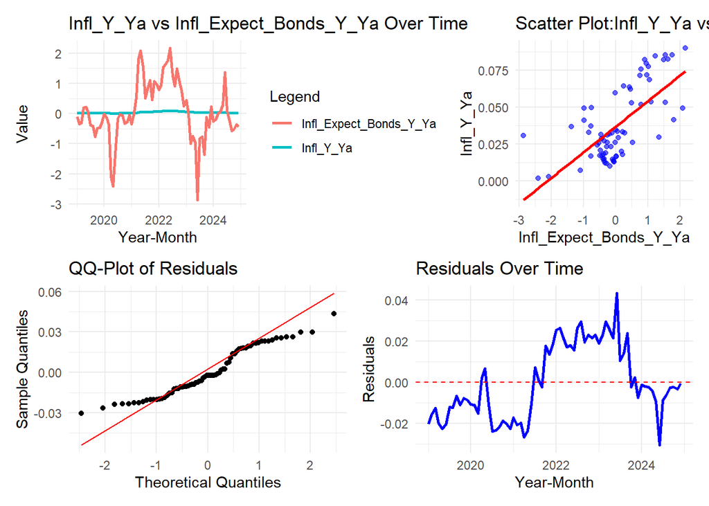

```r
print(result_bonds$plot_Y_Ya)
```

## Inflation Expectations, Surveyed

Units: Percent %  
Freq.: Monthly  
Transforms:

### Plot Histogram

### ADF Results

```r
stationary_test(table_survey, var_name) %>% cat()
```

```
## ADF Test Results for  Infl_Expect_Survey
##  As-Is:  0.974061354177076
##  M/M:    0.01
##  Y/Y:    0.741720986521665
```

### M/M Model Results and Durbin-Watson

### M/M Model Plots

### Y/Y Model Results and Durbin-Watson

```r
print(
  summary(result_survey$Model_Y_Ya)
)
```

```
##
## Call:
## lm(formula = as.formula(paste(response_col, "~", predictor_col)),
##     data = list_results[["merged_df"]])
##
## Residuals:
##       Min        1Q    Median        3Q       Max
## -0.038858 -0.017796 -0.001712  0.012690  0.043162
##
## Coefficients:
##                         Estimate Std. Error t value Pr(>|t|)
## (Intercept)             0.037923   0.002612  14.520  < 2e-16 ***
## Infl_Expect_Survey_Y_Ya 0.009723   0.002429   4.002 0.000154 ***
## ---
## Signif. codes:  0 '***' 0.001 '**' 0.01 '*' 0.05 '.' 0.1 ' ' 1
##
## Residual standard error: 0.02216 on 70 degrees of freedom
## Multiple R-squared:  0.1862, Adjusted R-squared:  0.1746
## F-statistic: 16.02 on 1 and 70 DF,  p-value: 0.000154
```

```r
print(
  result_survey$DW_Y_Ya
  )
```

```
##
##  Durbin-Watson test
##
## data:  list_results[["Model_Y_Ya"]]
## DW = 0.06784, p-value < 2.2e-16
## alternative hypothesis: true autocorrelation is greater than 0
```

### Y/Y Model Plots

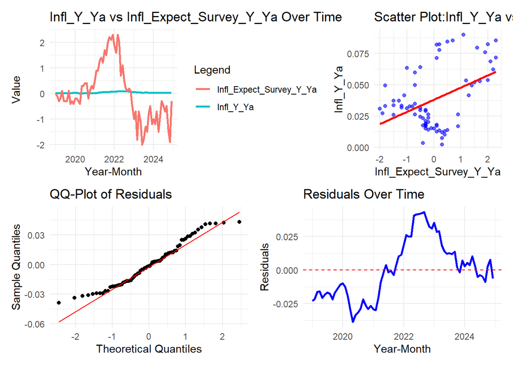

```r
print(result_survey$plot_Y_Ya)
```

# Public Policy Considerations

## Government Transfers to Persons

Units: Nominal $  
Freq.: Quarterly  
Transforms:

## Real Personal Expenditures

Units: Real $  
Freq.: Monthly  
Transforms:

### Plot Histogram

### ADF Results

```r
stationary_test(table_rpe, var_name) %>% cat()
```

```
## ADF Test Results for  R_Person_Expend
##  As-Is:  0.300478869622751
##  M/M:    0.01
##  Y/Y:    0.433337214818407
```

### M/M Model Results and Durbin-Watson

### M/M Model Plots

### Y/Y Model Results and Durbin-Watson

```r
print(
  summary(result_rpe$Model_Y_Ya)
)
```

```
##
## Call:
## lm(formula = as.formula(paste(response_col, "~", predictor_col)),
##     data = list_results[["merged_df"]])
##
## Residuals:
##       Min        1Q    Median        3Q       Max
## -0.042166 -0.016581 -0.006717  0.012923  0.053165
##
## Coefficients:
##             Estimate Std. Error t value Pr(>|t|)
## (Intercept) 0.032365   0.003093  10.462  5.9e-16 ***
## RPE_Y_Ya    0.200743   0.055649   3.607 0.000576 ***
## ---
## Signif. codes:  0 '***' 0.001 '**' 0.01 '*' 0.05 '.' 0.1 ' ' 1
##
## Residual standard error: 0.02256 on 70 degrees of freedom
## Multiple R-squared:  0.1568, Adjusted R-squared:  0.1447
## F-statistic: 13.01 on 1 and 70 DF,  p-value: 0.0005763
```

```r
print(
  result_rpe$DW_Y_Ya
  )
```

```
##
##  Durbin-Watson test
##
## data:  list_results[["Model_Y_Ya"]]
## DW = 0.078064, p-value < 2.2e-16
## alternative hypothesis: true autocorrelation is greater than 0
```

### Y/Y Model Plots

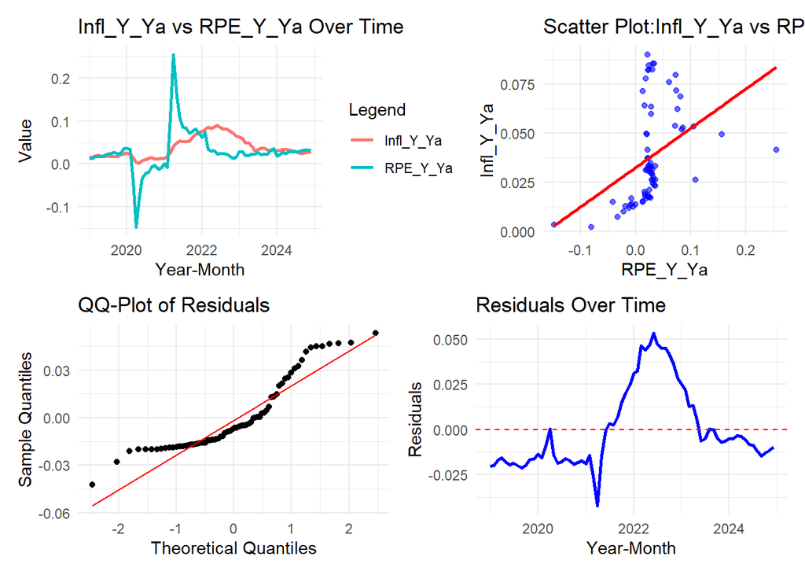

```r
print(result_rpe$plot_Y_Ya)
```

## Federal Reserve Interest Rate

Units: Interest Rate %  
Freq.: Daily  
Transforms:

### Plot Histogram

### ADF Results

```r
stationary_test(table_fed_rate, var_name) %>% cat()
```

```
## ADF Test Results for  Fed_Rate
##  As-Is:  0.483595164405878
##  M/M:    0.74368104762163
##  Y/Y:    0.639863014317505
```

### M/M Model Results and Durbin-Watson

### M/M Model Plots

### Y/Y Model Results and Durbin-Watson

```r
print(
  summary(result_fed_rate$Model_Y_Ya)
)
```

```
##
## Call:
## lm(formula = as.formula(paste(response_col, "~", predictor_col)),
##     data = list_results[["merged_df"]])
##
## Residuals:
##      Min       1Q   Median       3Q      Max
## -0.02804 -0.01365 -0.00686  0.01189  0.04920
##
## Coefficients:
##               Estimate Std. Error t value Pr(>|t|)
## (Intercept)   0.034336   0.002570   13.36  < 2e-16 ***
## Fed_Rate_Y_Ya 0.006941   0.001348    5.15 2.29e-06 ***
## ---
## Signif. codes:  0 '***' 0.001 '**' 0.01 '*' 0.05 '.' 0.1 ' ' 1
##
## Residual standard error: 0.02092 on 70 degrees of freedom
## Multiple R-squared:  0.2748, Adjusted R-squared:  0.2644
## F-statistic: 26.53 on 1 and 70 DF,  p-value: 2.288e-06
```

```r
print(
  result_fed_rate$DW_Y_Ya
  )
```

```
##
##  Durbin-Watson test
##
## data:  list_results[["Model_Y_Ya"]]
## DW = 0.05311, p-value < 2.2e-16
## alternative hypothesis: true autocorrelation is greater than 0
```

### Y/Y Model Plots

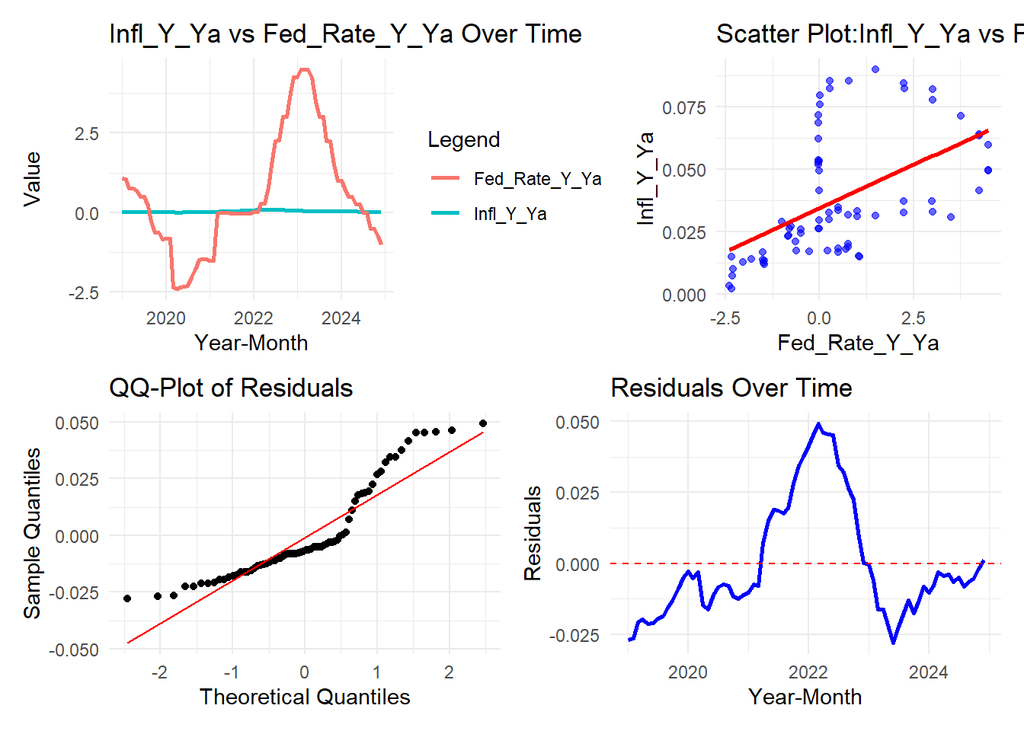

```r
print(result_fed_rate$plot_Y_Ya)
```

## Money Supply (M2)

Units: Real $  
Freq.: Monthly  
Transforms:

### Plot Histogram

### ADF Results

```r
stationary_test(table_supply, var_name) %>% cat()
```

```
## ADF Test Results for  Money_Supply
##  As-Is:  0.659613238573593
##  M/M:    0.224411085632005
##  Y/Y:    0.552518043476329
```

### M/M Model Results and Durbin-Watson

### M/M Model Plots

### Y/Y Model Results and Durbin-Watson

```r
print(
  summary(result_supply$Model_Y_Ya)
)
```

```
##
## Call:
## lm(formula = as.formula(paste(response_col, "~", predictor_col)),
##     data = list_results[["merged_df"]])
##
## Residuals:
##      Min       1Q   Median       3Q      Max
## -0.02432 -0.01692 -0.01113  0.01833  0.04434
##
## Coefficients:
##                 Estimate Std. Error t value Pr(>|t|)
## (Intercept)     0.042338   0.002674  15.835  < 2e-16 ***
## M2_Supply_Y_Ya -0.123836   0.026094  -4.746 1.07e-05 ***
## ---
## Signif. codes:  0 '***' 0.001 '**' 0.01 '*' 0.05 '.' 0.1 ' ' 1
##
## Residual standard error: 0.02137 on 70 degrees of freedom
## Multiple R-squared:  0.2434, Adjusted R-squared:  0.2326
## F-statistic: 22.52 on 1 and 70 DF,  p-value: 1.065e-05
```

```r
print(
  result_supply$DW_Y_Ya
  )
```

```
##
##  Durbin-Watson test
##
## data:  list_results[["Model_Y_Ya"]]
## DW = 0.029126, p-value < 2.2e-16
## alternative hypothesis: true autocorrelation is greater than 0
```

### Y/Y Model Plots

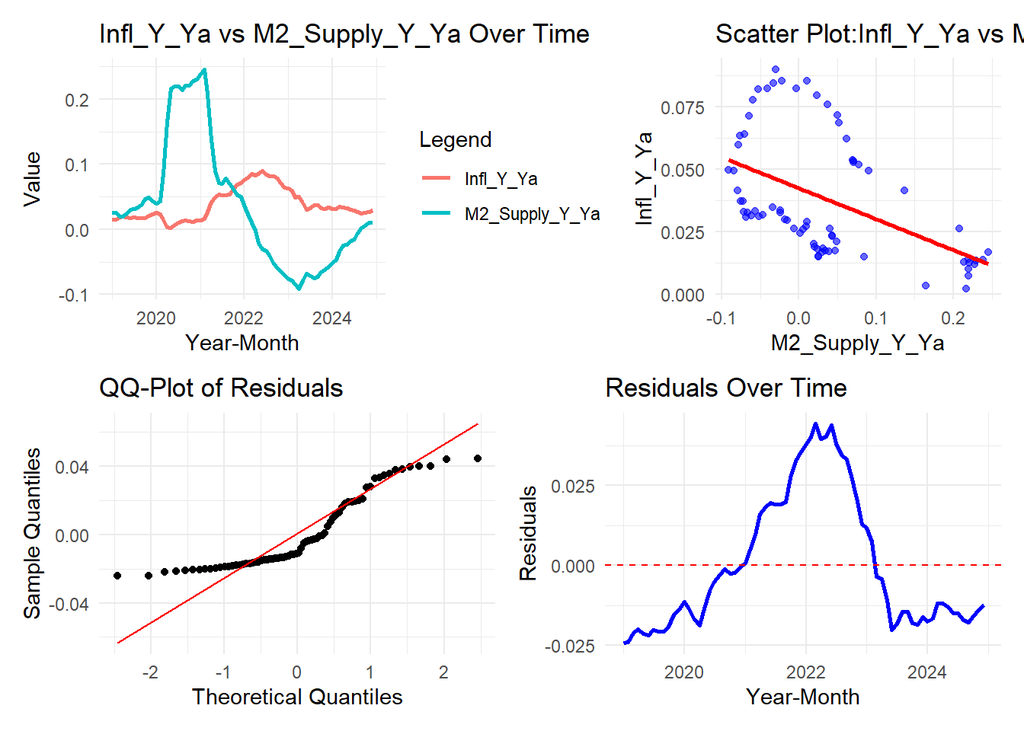

```r
print(result_supply$plot_Y_Ya)
```

## Velocity of Money (M2)

Units: Ratio  
Freq.: Quarterly  
Transforms:

## Junk Code